# Viagens a Serviço

Como parte do curso ‘Análise de Dados em Linguagem R’, avaliamos os gastos com viagens a serviço para tomar medidas mais eficientes.

Marcelo Bastos https://www.linkedin.com/in/marcelo-cabreira-bastos/

27 de fevereiro de 2023

# 1 Bibliotecas

```r
#install.packages("tictoc")

# Arquivos em html estavam sendo gerados, mas deu erro para arquivos .pdf. Por isso acrescentei as duas próximas linhas
#install.packages('tinytex')
#tinytex::install_tinytex()

library(readr)
library(data.table)
library(tictoc)
library(dplyr)
library(janitor)
library(tinytex)
library(httr)
```

# 2 Introdução e Créditos

Durante o módulo 4 do curso “Aplicação da linguagem R na análise de dados”, foi apresentado um estudo de caso sobre a análise de dados abertos de diárias e passagens. Com o objetivo de fixar o conhecimento adquirido e dar alguns passos além, foram realizados os seguintes processos:

1. Replicação do algoritmo utilizando o rmarkdown com saída em html;
2. Uso de bibliotecas adicionais para aprimorar a eficiência do código, como o janitor e o data.table, que permitem a limpeza e manipulação dos dados de forma mais rápida e fácil;
3. Proposição de um algoritmo para agregar diversos anos à análise de forma automática, através de um processo de raspagem dos dados, descompactação de arquivos e carga automática dos dados. Esse algoritmo permite que a análise possa ser feita em diversos anos de forma simples e eficiente, sem a necessidade de repetir manualmente os mesmos processos para cada conjunto de dados.

# 3 Definição do problema

Entender como ocorrem os gastos com viagens a serviço para tomar medidas mais eficientes e, com isso, reduzir os custos dessas viagens.

Euestões relevantes acerca dessa problemática:

Qual é o valor gasto por órgão? Qual é o valor gasto por cidade? Qual é a quantidade de viagens por mês?

Origem dos dados: - [Portal da Transparência](https://portaldatransparencia.gov.br/download-de-dados/viagens)

Durante o curso, foi feito com dados de 2019. Automatizar essa etapa. * https://portaldatransparencia.gov.br/download-de-dados/viagens/2019

[Dicionário de Dados – Viagens a Serviço – Pagamentos](https://portaldatransparencia.gov.br/pagina-interna/603364-dicion%C3%A1rio-de-dados-viagens-a-Servi%C3%A7o-Pagamentos)

# 4 Obtenção dos dados

## 4.1 Carga

```r
# Erro por causa do encoding

# tic()
# viagens_read_csv <- read.csv(
#   file = "data_raw/2019_Viagem.csv",
#   sep = ';',
#   dec = ','
# )
# toc()
```

```r
tic()
viagens_read_delim <- readr::read_delim("data_raw/2019_Viagem.csv",
                           delim = ";",
                           escape_double = FALSE,
                           locale = locale(encoding = "ISO-8859-1"),
                           trim_ws = TRUE)
tempo_decorrido <- toc()$callback_msg
```

[output not shown]

```r
tic()
viagensfread <- data.table::fread(input = "data_raw/2019_Viagem.csv",
                      sep = ";",
                      dec = ",",
                      header = TRUE,
                      encoding = "Latin-1",
                      strip.white = TRUE
)
tempo_decorrido <- toc()$callback_msg
```

```r
cat("Tempo de execução com 'fread':", format(tempo_decorrido, units="auto"))
```

```
## Tempo de execução com 'fread': 9.97 sec elapsed
```

```r
# Clean names and convert to tibble
viagens <- viagensfread %>%
  janitor::clean_names() %>%
  tibble::as_tibble()

# Table with equivalent names
original_col_names <- colnames(viagensfread)
clean_names <- names(setNames(viagens, names(viagens)))
name_mapping <- data.frame(original_col_names, clean_names)

# Remove tabelas que não serão mais utilizadas
remove(viagens_read_delim, viagensfread, tempo_decorrido, original_col_names, clean_names)
```

## 4.2 Visualização inicial

```r
#Visualizando as primeiras linhas do dataset - verificar se dados foram carregados corretamente
head(viagens)
```

```
## # A tibble: 6 × 22
##   identificado…¹ numer…² situa…³ viage…⁴ justi…⁵ codig…⁶ nome_…⁷ codig…⁸ nome_…⁹
##            <int> <chr>   <chr>   <chr>   <chr>     <int> <chr>     <int> <chr>
## 1       15045825 Sem in… Realiz… NÃO     Sem in…   26000 Minist…   26291 Fundaç…
## 2       15100682 Sem in… Realiz… NÃO     Sem in…   26000 Minist…   26291 Fundaç…
## 3       15114708 Sem in… Realiz… NÃO     Sem in…   26000 Minist…   26291 Fundaç…
## 4       15163874 Sem in… Realiz… NÃO     Sem in…   26000 Minist…   26291 Fundaç…
## 5       15166192 Sem in… Realiz… NÃO     Sem in…   26000 Minist…   26291 Fundaç…
## 6       15188479 Sem in… Realiz… NÃO     Sem in…   26000 Minist…   26291 Fundaç…
## # … with 13 more variables: cpf_viajante <chr>, nome <chr>, cargo <chr>,
## #   funcao <chr>, descricao_funcao <chr>, periodo_data_de_inicio <chr>,
## #   periodo_data_de_fim <chr>, destinos <chr>, motivo <chr>,
## #   valor_diarias <dbl>, valor_passagens <dbl>, valor_devolucao <dbl>,
## #   valor_outros_gastos <dbl>, and abbreviated variable names
## #   ¹identificador_do_processo_de_viagem, ²numero_da_proposta_pcdp, ³situacao,
## #   ⁴viagem_urgente, ⁵justificativa_urgencia_viagem, …
```

```r
#View(viagens)

#Verificar dimensões do dataset
dim(viagens)
```

```
## [1] 844130     22
```

```r
#Resumo do dataset - valores min, max, media, mediana...
summary(viagens)
```

```
##  identificador_do_processo_de_viagem numero_da_proposta_pcdp   situacao
##  Min.   :1.505e+07                   Length:844130           Length:844130
##  1st Qu.:1.602e+07                   Class :character        Class :character
##  Median :1.629e+07                   Mode  :character        Mode  :character
##  Mean   :2.098e+07
##  3rd Qu.:1.655e+07
##  Max.   :2.019e+09
##  viagem_urgente     justificativa_urgencia_viagem codigo_do_orgao_superior
##  Length:844130      Length:844130                 Min.   :   -1
##  Class :character   Class :character              1st Qu.:26000
##  Mode  :character   Mode  :character              Median :30000
##                                                   Mean   :33087
##                                                   3rd Qu.:44000
##                                                   Max.   :84000
##  nome_do_orgao_superior codigo_orgao_solicitante nome_orgao_solicitante
##  Length:844130          Min.   :   -1            Length:844130
##  Class :character       1st Qu.:26000            Class :character
##  Mode  :character       Median :26436            Mode  :character
##                         Mean   :31001
##                         3rd Qu.:37202
##                         Max.   :91214
##  cpf_viajante           nome              cargo              funcao
##  Length:844130      Length:844130      Length:844130      Length:844130
##  Class :character   Class :character   Class :character   Class :character
##  Mode  :character   Mode  :character   Mode  :character   Mode  :character
##
##
##
##  descricao_funcao   periodo_data_de_inicio periodo_data_de_fim
##  Length:844130      Length:844130          Length:844130
##  Class :character   Class :character       Class :character
##  Mode  :character   Mode  :character       Mode  :character
##
##
##
##    destinos            motivo          valor_diarias      valor_passagens
##  Length:844130      Length:844130      Min.   :     0.0   Min.   :     0.0
##  Class :character   Class :character   1st Qu.:    88.5   1st Qu.:     0.0
##  Mode  :character   Mode  :character   Median :   431.3   Median :     0.0
##                                        Mean   :   959.7   Mean   :   592.4
##                                        3rd Qu.:   817.2   3rd Qu.:   898.7
##                                        Max.   :131223.7   Max.   :155531.4
##  valor_devolucao    valor_outros_gastos
##  Min.   :    0.00   Min.   :    0.00
##  1st Qu.:    0.00   1st Qu.:    0.00
##  Median :    0.00   Median :    0.00
##  Mean   :   14.13   Mean   :    9.77
##  3rd Qu.:    0.00   3rd Qu.:    0.00
##  Max.   :29546.00   Max.   :12497.54
```

```r
#Summary de uma coluna especifica
summary(viagens$valor_passagens)
```

```
##     Min.  1st Qu.   Median     Mean  3rd Qu.     Max.
##      0.0      0.0      0.0    592.4    898.7 155531.4
```

```r
#Verificar tipo dos dados
dplyr::glimpse(viagens)
```

```
## Rows: 844,130
## Columns: 22
## $ identificador_do_processo_de_viagem <int> 15045825, 15100682, 15114708, 1516…
## $ numero_da_proposta_pcdp             <chr> "Sem informação", "Sem informação"…
## $ situacao                            <chr> "Realizada", "Realizada", "Realiza…
## $ viagem_urgente                      <chr> "NÃO", "NÃO", "NÃO", "NÃO", "NÃO",…
## $ justificativa_urgencia_viagem       <chr> "Sem informação", "Sem informação"…
## $ codigo_do_orgao_superior            <int> 26000, 26000, 26000, 26000, 26000,…
## $ nome_do_orgao_superior              <chr> "Ministério da Educação", "Ministé…
## $ codigo_orgao_solicitante            <int> 26291, 26291, 26291, 26291, 26291,…
## $ nome_orgao_solicitante              <chr> "Fundação Coordenação de Aperfeiço…
## $ cpf_viajante                        <chr> "***.377.624-**", "***.831.975-**"…
## $ nome                                <chr> "MARINA FERREIRA KITAZONO ANTUNES"…
## $ cargo                               <chr> "", "", "PESQUISADOR EM GEOCIENCIA…
## $ funcao                              <chr> "-1", "-1", "-1", "-1", "-1", "-1"…
## $ descricao_funcao                    <chr> "Não Informado", "Não Informado", …
## $ periodo_data_de_inicio              <chr> "06/02/2019", "01/02/2019", "01/02…
## $ periodo_data_de_fim                 <chr> "07/02/2019", "02/02/2019", "01/02…
## $ destinos                            <chr> "Recife/PE", "Recife/PE", "São Pau…
## $ motivo                              <chr> "Regresso de bolsista CAPES do ext…
## $ valor_diarias                       <dbl> 0.00, 0.00, 0.00, 0.00, 0.00, 0.00…
## $ valor_passagens                     <dbl> 3406.33, 2925.83, 2760.02, 2875.92…
## $ valor_devolucao                     <dbl> 0, 0, 0, 0, 0, 0, 0, 0, 0, 0, 0, 0…
## $ valor_outros_gastos                 <dbl> 0, 0, 0, 0, 0, 0, 0, 0, 0, 0, 0, 0…
```

# 5 TRANSFORMAÇÃO DOS DADOS OBTIDOS

## 5.1 Datas

```r
#Convertendo o tipo do dato para tipo Date
#?as.Date

viagens$data_inicio <- as.Date(viagens$periodo_data_de_inicio, "%d/%m/%Y")
glimpse(viagens)
```

```
## Rows: 844,130
## Columns: 23
## $ identificador_do_processo_de_viagem <int> 15045825, 15100682, 15114708, 1516…
## $ numero_da_proposta_pcdp             <chr> "Sem informação", "Sem informação"…
## $ situacao                            <chr> "Realizada", "Realizada", "Realiza…
## $ viagem_urgente                      <chr> "NÃO", "NÃO", "NÃO", "NÃO", "NÃO",…
## $ justificativa_urgencia_viagem       <chr> "Sem informação", "Sem informação"…
## $ codigo_do_orgao_superior            <int> 26000, 26000, 26000, 26000, 26000,…
## $ nome_do_orgao_superior              <chr> "Ministério da Educação", "Ministé…
## $ codigo_orgao_solicitante            <int> 26291, 26291, 26291, 26291, 26291,…
## $ nome_orgao_solicitante              <chr> "Fundação Coordenação de Aperfeiço…
## $ cpf_viajante                        <chr> "***.377.624-**", "***.831.975-**"…
## $ nome                                <chr> "MARINA FERREIRA KITAZONO ANTUNES"…
## $ cargo                               <chr> "", "", "PESQUISADOR EM GEOCIENCIA…
## $ funcao                              <chr> "-1", "-1", "-1", "-1", "-1", "-1"…
## $ descricao_funcao                    <chr> "Não Informado", "Não Informado", …
## $ periodo_data_de_inicio              <chr> "06/02/2019", "01/02/2019", "01/02…
## $ periodo_data_de_fim                 <chr> "07/02/2019", "02/02/2019", "01/02…
## $ destinos                            <chr> "Recife/PE", "Recife/PE", "São Pau…
## $ motivo                              <chr> "Regresso de bolsista CAPES do ext…
## $ valor_diarias                       <dbl> 0.00, 0.00, 0.00, 0.00, 0.00, 0.00…
## $ valor_passagens                     <dbl> 3406.33, 2925.83, 2760.02, 2875.92…
## $ valor_devolucao                     <dbl> 0, 0, 0, 0, 0, 0, 0, 0, 0, 0, 0, 0…
## $ valor_outros_gastos                 <dbl> 0, 0, 0, 0, 0, 0, 0, 0, 0, 0, 0, 0…
## $ data_inicio                         <date> 2019-02-06, 2019-02-01, 2019-02-0…
```

```r
#Formatando a data de inicio - para utilizar apenas Ano/Mês
#?format
viagens$data_inicio_formatada <- format(viagens$data_inicio, "%Y-%m")
dplyr::glimpse(viagens)
```

```
## Rows: 844,130
## Columns: 24
## $ identificador_do_processo_de_viagem <int> 15045825, 15100682, 15114708, 1516…
## $ numero_da_proposta_pcdp             <chr> "Sem informação", "Sem informação"…
## $ situacao                            <chr> "Realizada", "Realizada", "Realiza…
## $ viagem_urgente                      <chr> "NÃO", "NÃO", "NÃO", "NÃO", "NÃO",…
## $ justificativa_urgencia_viagem       <chr> "Sem informação", "Sem informação"…
## $ codigo_do_orgao_superior            <int> 26000, 26000, 26000, 26000, 26000,…
## $ nome_do_orgao_superior              <chr> "Ministério da Educação", "Ministé…
## $ codigo_orgao_solicitante            <int> 26291, 26291, 26291, 26291, 26291,…
## $ nome_orgao_solicitante              <chr> "Fundação Coordenação de Aperfeiço…
## $ cpf_viajante                        <chr> "***.377.624-**", "***.831.975-**"…
## $ nome                                <chr> "MARINA FERREIRA KITAZONO ANTUNES"…
## $ cargo                               <chr> "", "", "PESQUISADOR EM GEOCIENCIA…
## $ funcao                              <chr> "-1", "-1", "-1", "-1", "-1", "-1"…
## $ descricao_funcao                    <chr> "Não Informado", "Não Informado", …
## $ periodo_data_de_inicio              <chr> "06/02/2019", "01/02/2019", "01/02…
## $ periodo_data_de_fim                 <chr> "07/02/2019", "02/02/2019", "01/02…
## $ destinos                            <chr> "Recife/PE", "Recife/PE", "São Pau…
## $ motivo                              <chr> "Regresso de bolsista CAPES do ext…
## $ valor_diarias                       <dbl> 0.00, 0.00, 0.00, 0.00, 0.00, 0.00…
## $ valor_passagens                     <dbl> 3406.33, 2925.83, 2760.02, 2875.92…
## $ valor_devolucao                     <dbl> 0, 0, 0, 0, 0, 0, 0, 0, 0, 0, 0, 0…
## $ valor_outros_gastos                 <dbl> 0, 0, 0, 0, 0, 0, 0, 0, 0, 0, 0, 0…
## $ data_inicio                         <date> 2019-02-06, 2019-02-01, 2019-02-0…
## $ data_inicio_formatada               <chr> "2019-02", "2019-02", "2019-02", "…
```

# 6 Exploração dos dados

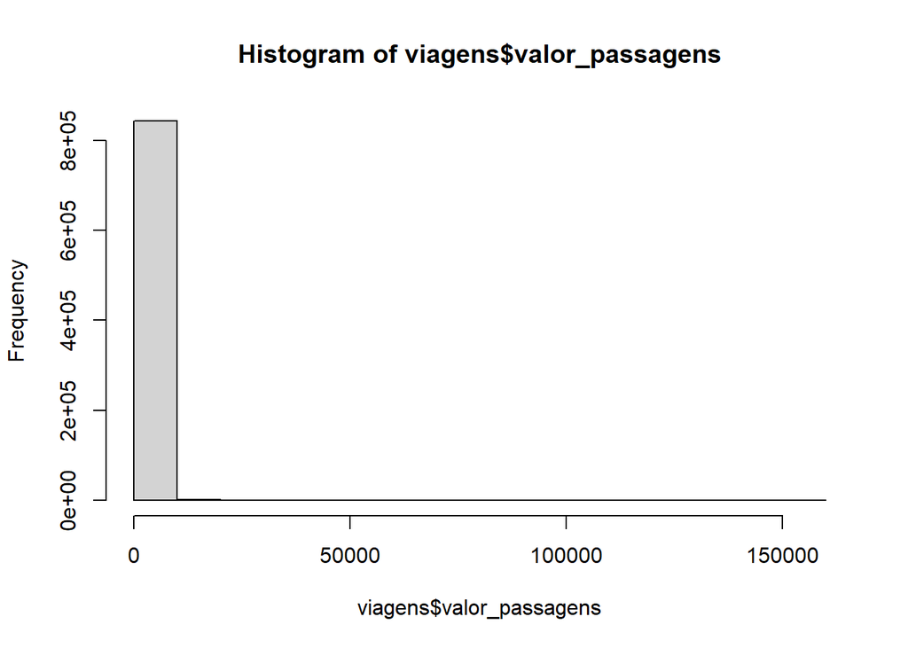

```r
#Gerando histograma da coluna passagens
hist(viagens$valor_passagens)
```

```r
#Filtrando os valores das passagens - apenas passagens entre 200 e 5000
passagens_fitro <- viagens %>%
  select(valor_passagens) %>%
  filter(valor_passagens >= 200 & valor_passagens <= 5000)


passagens_fitro
```

```
## # A tibble: 249,334 × 1
##    valor_passagens
##              <dbl>
##  1           3406.
##  2           2926.
##  3           2760.
##  4           2876.
##  5           2420.
##  6           1262.
##  7           2695.
##  8           1236.
##  9            746.
## 10           1293.
## # … with 249,324 more rows
```

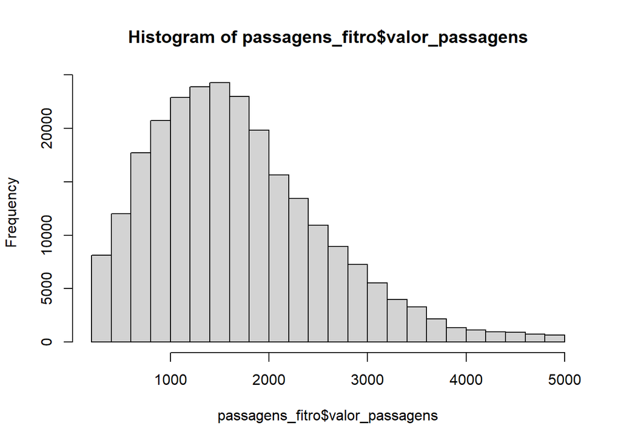

```r
hist(passagens_fitro$valor_passagens)
```

```r
#Verificando os valores min, max, média... da coluna valor
summary(viagens$valor_passagens)
```

```
##     Min.  1st Qu.   Median     Mean  3rd Qu.     Max.
##      0.0      0.0      0.0    592.4    898.7 155531.4
```

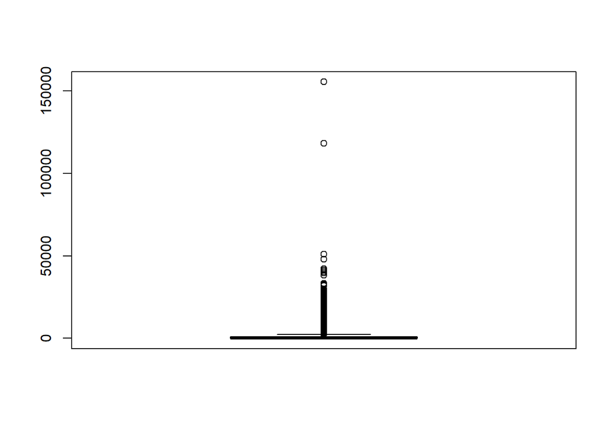

```r
#Visualizando os valores em um boxplot
boxplot(viagens$valor_passagens)
```

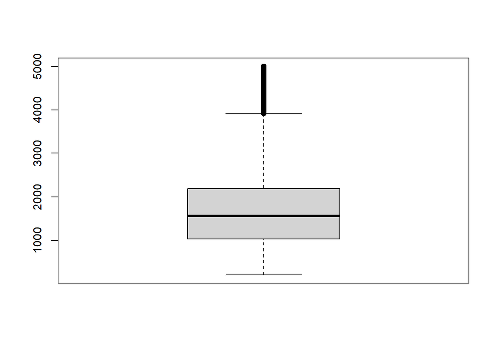

```r
#Visualizando os valores das passagens - filtro de 200 a 5000
boxplot(passagens_fitro$valor_passagens)
```

```r
#Calculando o desvio padrão
sd(viagens$valor_passagens)
```

```
## [1] 1292.185
```

```r
#Verificar se existem valores não preenchidos nas colunas do dataframe
colSums(is.na(viagens))
```

```
## identificador_do_processo_de_viagem             numero_da_proposta_pcdp
##                                   0                                   0
##                            situacao                      viagem_urgente
##                                   0                                   0
##       justificativa_urgencia_viagem            codigo_do_orgao_superior
##                                   0                                   0
##              nome_do_orgao_superior            codigo_orgao_solicitante
##                                   0                                   0
##              nome_orgao_solicitante                        cpf_viajante
##                                   0                                   0
##                                nome                               cargo
##                                   0                                   0
##                              funcao                    descricao_funcao
##                                   0                                   0
##              periodo_data_de_inicio                 periodo_data_de_fim
##                                   0                                   0
##                            destinos                              motivo
##                                   0                                   0
##                       valor_diarias                     valor_passagens
##                                   0                                   0
##                     valor_devolucao                 valor_outros_gastos
##                                   0                                   0
##                         data_inicio               data_inicio_formatada
##                                   0                                   0
```

```r
#Verifcar a quantidade de categorias da coluna Situação

#Converter para factor
viagens$Situação <- factor(viagens$situacao)

str(viagens$situacao)
```

```
##  chr [1:844130] "Realizada" "Realizada" "Realizada" "Realizada" "Realizada" ...
```

```r
#Verificar quantidade de registros em cada categoria
table(viagens$situacao)
```

```
##
## Não realizada     Realizada
##         19356        824774
```

```r
#Obtendo os valores em percentual de cada categoria
prop.table(table(viagens$situacao))*100
```

```
##
## Não realizada     Realizada
##      2.293012     97.706988
```

# 7 Visualização dos resultados

## 7.1 1 - Qual é o valor gasto por órgão em passagens?

```r
#Criando um dataframe com os 15 órgãos que gastam mais
p1 <- viagens %>%
  group_by(nome_do_orgao_superior) %>%
  summarise(n = sum(valor_passagens)) %>%
  arrange(desc(n)) %>%
  top_n(15)
#Alterando o nome das colunas
names(p1) <- c("orgao", "valor")
p1
```

```
## # A tibble: 15 × 2
##    orgao                                                            valor
##    <chr>                                                            <dbl>
##  1 Ministério da Educação                                      111865171.
##  2 Ministério da Defesa                                         85451635
##  3 Sem informação                                               55168928.
##  4 Ministério da Justiça e Segurança Pública                    45394977.
##  5 Ministério da Saúde                                          34529876.
##  6 Ministério das Relações Exteriores                           20852388.
##  7 Ministério do Meio Ambiente                                  19315832.
##  8 Ministério da Infraestrutura                                 18902660.
##  9 Ministério da Agricultura, Pecuária e Abastecimento          12501076.
## 10 Ministério de Minas e Energia                                11218111.
## 11 Ministério da Ciência, Tecnologia, Inovações e Comunicações  11122494.
## 12 Presidência da República                                     10701502.
## 13 Ministério da Previdência Social                              9726906.
## 14 Ministério da Economia                                        7057171
## 15 Ministério das Comunicações                                   5435848.
```

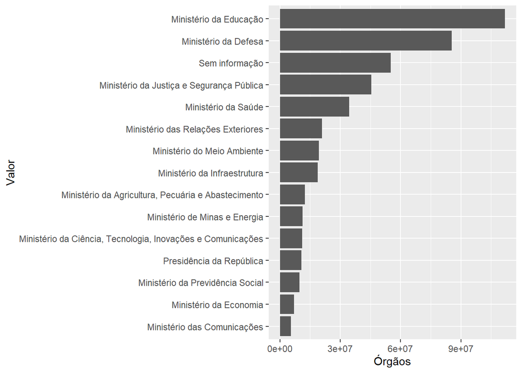

```r
#Plotando os dados com o ggplot
library(ggplot2)
ggplot(p1, aes(x = reorder(orgao, valor), y = valor))+
  geom_bar(stat = "identity")+
  coord_flip()+
  labs(x = "Valor", y = "Órgãos")
```

## 7.2 2 - Qual é o valor gasto por cidade?

```r
#Criando um dataframe com as 15 cidades que gastam mais
p2 <- viagens %>%
  group_by(destinos) %>%
  summarise(n = sum(valor_passagens)) %>%
  arrange(desc(n)) %>%
  top_n(15)
#Alterando o nome das colunas
names(p2) <- c("destino", "valor")
p2
```

```
## # A tibble: 15 × 2
##    destino                               valor
##    <chr>                                 <dbl>
##  1 Brasília/DF                       96228368.
##  2 Informações protegidas por sigilo 54039084.
##  3 Rio de Janeiro/RJ                 33257006.
##  4 São Paulo/SP                      28260409.
##  5 Sem informação                    23990942.
##  6 Manaus/AM                         10024657.
##  7 Recife/PE                          7920869.
##  8 Belo Horizonte/MG                  7244578.
##  9 Curitiba/PR                        7158178.
## 10 Porto Alegre/RS                    6811612.
## 11 Belém/PA                           6718393.
## 12 Salvador/BA                        6355919.
## 13 Foz do Iguaçu/PR                   6032982.
## 14 São José dos Campos/SP             5555788.
## 15 Florianópolis/SC                   5340613.
```

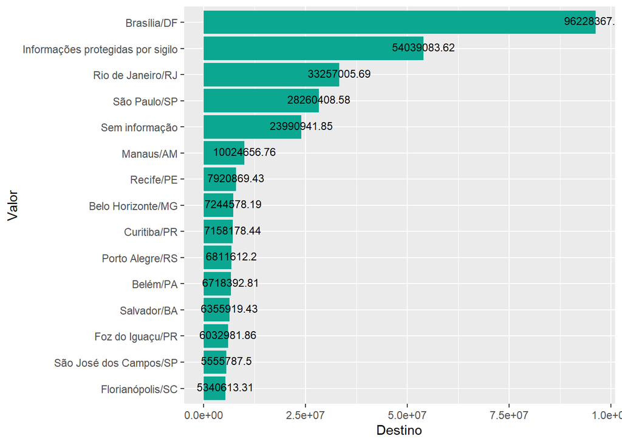

```r
#Criando o gráfico
ggplot(p2, aes(x = reorder(destino, valor), y = valor))+
  geom_bar(stat = "identity", fill = "#0ba791")+
  geom_text(aes(label = valor), vjust = 0.3, size = 3)+
  coord_flip()+
  labs(x = "Valor", y = "Destino")
```

## 7.3 3 - Qual é a quantidade de viagens por mês?

```r
#Criando um dataframe com a quantidade de viagens por Ano/mês
p3 <- viagens %>%
  group_by(data_inicio_formatada) %>%
  summarise(qtd = n_distinct(identificador_do_processo_de_viagem))

head(p3)
```

```
## # A tibble: 6 × 2
##   data_inicio_formatada   qtd
##   <chr>                 <int>
## 1 2019-01               31021
## 2 2019-02               56023
## 3 2019-03               65171
## 4 2019-04               70729
## 5 2019-05               79850
## 6 2019-06               73394
```

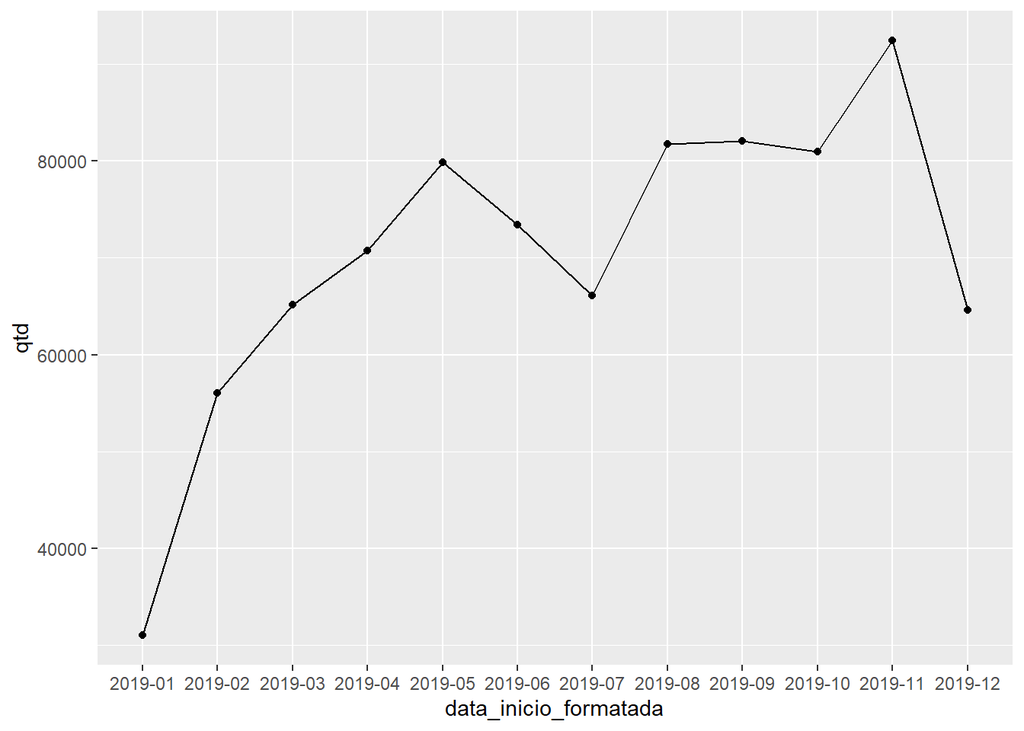

```r
#Criando o gráfico
ggplot(p3, aes(x = data_inicio_formatada, y = qtd, group = 1))+
  geom_line()+
  geom_point()
```

# 8 Ideias

## 8.1 Poderia ser feita a avaliação histórica desses dados?

Sim!

## 8.2 Como automatizar a extração?

Segue uma proposta em 3 etapas:

1- Baixar os dados 2- Fazer o unzip 3- Carga dos dados

### 8.2.1 1- Baixar os dados

```r
setwd("data_raw")

anos <- 2019:2023
base_url <- "https://portaldatransparencia.gov.br/download-de-dados/viagens/"

for (ano in anos) {
  url <- paste0(base_url, ano)
  filename <- paste0("viagens_", ano, ".zip")

  response <- GET(url)
  writeBin(content(response, "raw"), filename)

  message(paste("Arquivo", filename, "baixado com sucesso."))
}
```

```
## Arquivo viagens_2019.zip baixado com sucesso.
```

```
## Arquivo viagens_2020.zip baixado com sucesso.
```

```
## Arquivo viagens_2021.zip baixado com sucesso.
```

```
## Arquivo viagens_2022.zip baixado com sucesso.
```

```
## Arquivo viagens_2023.zip baixado com sucesso.
```

### 8.2.2 2- Fazer o unzip

```r
setwd("data_raw")

for (ano in anos) {
  arquivo_zip <- paste0("viagens_", ano, ".zip")
  unzip(arquivo_zip)
  message(paste("Arquivo", arquivo_zip, "unzip."))
}
```

```
## Arquivo viagens_2019.zip unzip.
```

```
## Arquivo viagens_2020.zip unzip.
```

```
## Arquivo viagens_2021.zip unzip.
```

```
## Arquivo viagens_2022.zip unzip.
```

```
## Arquivo viagens_2023.zip unzip.
```

### 8.2.3 3- Carga dos dados

```r
carregar_viagem <- function(ano, nome_arquivo) {
  caminho <- file.path("data_raw/", paste0(ano, "_", nome_arquivo,".csv"))
  fread(caminho, sep = ";", dec = ",", header = TRUE, encoding = "Latin-1", strip.white = TRUE)%>%
  janitor::clean_names() %>%
  tibble::as_tibble()
}

viagens <- data.table()
for (ano in anos) {
  dt_temp <- carregar_viagem(ano,"Viagem")
  viagens <- rbindlist(list(viagens, dt_temp))
}

remove(dt_temp,anos, ano)
```

## 8.3 Exemplo: Qual é o valor gasto por órgão em passagens?

```r
#Criando um dataframe com os 15 órgãos que gastam mais
p1_varios_anos <- viagens %>%
  group_by(nome_do_orgao_superior) %>%
  summarise(n = sum(valor_passagens)) %>%
  arrange(desc(n)) %>%
  top_n(15)%>%
  mutate(classificacao = paste0(rank(desc(n)), "º"))
#Alterando o nome das colunas
names(p1_varios_anos) <- c("orgao", "valor",  "classificacao 2019-2023")
p1_varios_anos
```

```
## # A tibble: 15 × 3
##    orgao                                                           valor class…¹
##    <chr>                                                           <dbl> <chr>
##  1 Ministério da Defesa                                           2.89e8 1º
##  2 Ministério da Educação                                         2.21e8 2º
##  3 Sem informação                                                 1.79e8 3º
##  4 Ministério da Justiça e Segurança Pública                      1.65e8 4º
##  5 Ministério da Saúde                                            9.16e7 5º
##  6 Ministério das Relações Exteriores                             7.89e7 6º
##  7 Ministério do Meio Ambiente                                    5.56e7 7º
##  8 Ministério da Infraestrutura                                   5.33e7 8º
##  9 Presidência da República                                       4.67e7 9º
## 10 Ministério da Agricultura, Pecuária e Abastecimento            3.71e7 10º
## 11 Ministério da Previdência Social                               3.62e7 11º
## 12 Ministério de Minas e Energia                                  2.66e7 12º
## 13 Ministério da Ciência, Tecnologia, Inovações e Comunicações    2.22e7 13º
## 14 Ministério do Desenvolvimento Agrário                          1.39e7 14º
## 15 Secretaria de Direitos Humanos                                 1.36e7 15º
## # … with abbreviated variable name ¹`classificacao 2019-2023`
```

Camparando o resultado com órgãos que mais gastaram em 2019 com os mais gataram considerando todo o período (2019 até 2023)

```r
# Colocando o rrankeamento no p1 2019
p1 <- p1 %>%
  mutate(classificacao_2019 = paste0(row_number(), "º"))

dplyr::full_join(p1_varios_anos,p1, by="orgao")
```

```
## # A tibble: 17 × 5
##    orgao                                         valor.x class…¹ valor.y class…²
##    <chr>                                           <dbl> <chr>     <dbl> <chr>
##  1 Ministério da Defesa                           2.89e8 1º       8.55e7 2º
##  2 Ministério da Educação                         2.21e8 2º       1.12e8 1º
##  3 Sem informação                                 1.79e8 3º       5.52e7 3º
##  4 Ministério da Justiça e Segurança Pública      1.65e8 4º       4.54e7 4º
##  5 Ministério da Saúde                            9.16e7 5º       3.45e7 5º
##  6 Ministério das Relações Exteriores             7.89e7 6º       2.09e7 6º
##  7 Ministério do Meio Ambiente                    5.56e7 7º       1.93e7 7º
##  8 Ministério da Infraestrutura                   5.33e7 8º       1.89e7 8º
##  9 Presidência da República                       4.67e7 9º       1.07e7 12º
## 10 Ministério da Agricultura, Pecuária e Abaste…  3.71e7 10º      1.25e7 9º
## 11 Ministério da Previdência Social               3.62e7 11º      9.73e6 13º
## 12 Ministério de Minas e Energia                  2.66e7 12º      1.12e7 10º
## 13 Ministério da Ciência, Tecnologia, Inovações…  2.22e7 13º      1.11e7 11º
## 14 Ministério do Desenvolvimento Agrário          1.39e7 14º     NA      <NA>
## 15 Secretaria de Direitos Humanos                 1.36e7 15º     NA      <NA>
## 16 Ministério da Economia                        NA      <NA>     7.06e6 14º
## 17 Ministério das Comunicações                   NA      <NA>     5.44e6 15º
## # … with abbreviated variable names ¹`classificacao 2019-2023`,
## #   ²classificacao_2019
```